# UIN Malang Internet User Analysis

Analisis Demografi Pengguna Internet pada Mahasiswa Baru UIN Malang dan Menentukan Resiko Adiksi Internet dengan Depresi, Anxiety, dan Stress

Mely Santoso

10/30/2020

# 1 **Pendahuluan (Tentang)**

Saya berlatarbelakang lulusan jurusan psikologi dari UIN Malang. Kesibukan saya saat ini yang paling utama adalah salat 5 waktu dan mengajar mengaji

Mari terhubung di twitter himelysantoso atau instagram [melysantoso](https://www.instagram.com/melysantoso/) untuk mendiskusikan atau sekedar menyapa.

Jika Anda tertarik dengan tulisan berbasis data atau penjelasan berbasis sains, coba tengok tulisan-tulisan user story saya di [Kumparan](https://kumparan.com/melysantoso) (akhir-akhir ini meliput COVID-19). Atau tulisan lain saya yang membahas psikologi di [Medium](https://medium.com/@bukakurung)

# 2 **Persiapan Data (Merapikan, Eksplorasi, dan Membersihkan Data yang Tidak Dibutuhkan)**

Data yang digunakan dalam analisis ini adalah data pribadi dari skripsi saya

Data ini dikumpulkan dari mahasiswa baru tahun 2018 lalu

Data yang dianalisis ini terdiri dari dua kategori utama yaitu 1) data demografi dan; 2) data psikologis

Jika tertarik membaca skripsi saya silahkan kunjungi [Link ini](http://etheses.uin-malang.ac.id/13584/)

*Catatan*

- Untuk kepentingan kerahasiaan responden kita buang data yang bersifat privat seperti nama dan email
- Variabel “Asal” tidak seberapa baik datanya jadi kita buang
- Untuk mempelajari membuat kategorisasi di R, kita buang variabel “Addicted”
- Sebenarnya ada 1 variabel lain yaitu insomnia, tapi dalam laporan ini tidak digunakan karena hasil reliabilitas dan validitas skalanya tidak bagus

```r
#Import library()
library(ggplot2)
library(reshape2)
library(tidyverse)
library(dplyr)
library(gridExtra)
library(ggalluvial)
library(treemapify)
library(ggcorrplot)
library(visreg)
library(vcd)
library(correlation)
library(kableExtra)

# 1) IMPORT & DATA CLEANING

# a) Masukkan data
internetdata <- read.csv("datainternet.csv")
#View(internetdata) #untuk melihat data
#glimpse(internetdata) #tidy up nama-nama variable
#table(internetdata$Usia) #akses spesifik variabel

# b) Buang observasi yang bersifat private dan tidak dibutuhkan
internetdata <- internetdata %>%
  select(-c("Nama", "Email", "Asal", "Addicted"))


# c) Beberapa data dijadikan nominal
data_nominal <- (c("Sex", "Fakultas", "Pendidikan", "Device", "WiFi",
                   "Koneksi", "Alasan", "MedSos", "Lembur", "Layanan",
                   "Situs", "Waktu", "Tempat"))
internetdata[data_nominal] <- lapply(internetdata[data_nominal], function(x){factor(x)})

# d) Obs Durasi dijadikan ordinal aja biar bisa dianalisis
internetdata$Durasi <- factor(internetdata$Durasi,
                              ordered = T,
                              levels = c("1- 3 Jam",
                                         "4 - 7 Jam",
                                         "> 7 Jam"))


# 2) OTHER DATA ISSUEs
# Karena ini adalah data pengukuran psikologi maka ada beberapa hal yang harus dilakukan

#) a) Buat kategori kelompok adiksi dan non adiksi
internetdata$Kategori <- ifelse(internetdata$IA <= round(mean(internetdata$IA)), "nonadiksi", "adiksi")


# Cek datanya
glimpse(internetdata)
```

```
## Rows: 446
## Columns: 20
## $ Sex        <fct> Laki-laki, Laki-laki, Laki-laki, Laki-laki, Perempuan, L...
## $ Usia       <int> 19, 19, 18, 19, 19, 18, 18, 18, 18, 18, 18, 18, 20, 17, ...
## $ Fakultas   <fct> FITK, FITK, FITK, FITK, FITK, FITK, FITK, FITK, FITK, FI...
## $ Pendidikan <fct> MA, MA, SMA, Pondok Pesantren, MA, SMA, MA, Pondok Pesan...
## $ Durasi     <ord> > 7 Jam, 4 - 7 Jam, 4 - 7 Jam, > 7 Jam, 4 - 7 Jam, 4 - 7...
## $ Device     <fct> Smart Phone, Smart Phone, Smart Phone, Smart Phone, Smar...
## $ WiFi       <fct> Ada dong!, Ada dong!, Ada dong!, Ada dong!, Ada dong!, A...
## $ Koneksi    <fct> Paket Data, Paket Data, WiFi, Paket Data, WiFi, Paket Da...
## $ Alasan     <fct> Bersosialisasi, Bersosialisasi, Mengisi waktu luang, Ter...
## $ MedSos     <fct> WhatsApp, WhatsApp, Instagram, WhatsApp, WhatsApp, Insta...
## $ Lembur     <fct> Iya, Iya, Iya, Tidak, Tidak, Tidak, Tidak, Iya, Iya, Iya...
## $ Layanan    <fct> Browsing, Chatting, Media Sosial, Nonton vidio, Media So...
## $ Situs      <fct> "Gramedia", "Facebook.com", "Seni ", "Wikipedia", "Berit...
## $ Waktu      <fct> Menunggu sesuatu (contoh : menunggu dosen), Menjelang ti...
## $ Tempat     <fct> Kamar, Kamar, Kamar, Kalau lagi boring, Kamar, Dimanapun...
## $ IA         <int> 21, 40, 86, 18, 13, 23, 36, 2, 54, 40, 47, 29, 54, 20, 3...
## $ Depresi    <int> 14, 18, 19, 2, 2, 0, 41, 1, 0, 0, 9, 4, 10, 36, 4, 8, 8,...
## $ Anxiety    <int> 14, 17, 29, 8, 3, 2, 35, 2, 7, 7, 15, 5, 13, 42, 8, 16, ...
## $ Stress     <int> 14, 21, 35, 7, 1, 0, 40, 0, 3, 1, 18, 9, 14, 42, 5, 18, ...
## $ Kategori   <chr> "nonadiksi", "adiksi", "adiksi", "nonadiksi", "nonadiksi...
```

*Catatan*

# 3 **Visualisasi dan Analisa Data Demografi**

Analisi demografi dimaksudkan untuk mengetahui gambaran besar tentang karakteristik responden dengan mencari kesamaan-kesamaan antara mereka

## 3.1 Jenis Kelamin dan Fakultas Responden

Data ini diambil dari mahasiswa baru UIN Malang tahun 2018 untuk itu kita membuat dulu visualisasi dasar untuk mengetahui kategorisasi dari jenis kelamin dan fakultas masing-masing responden

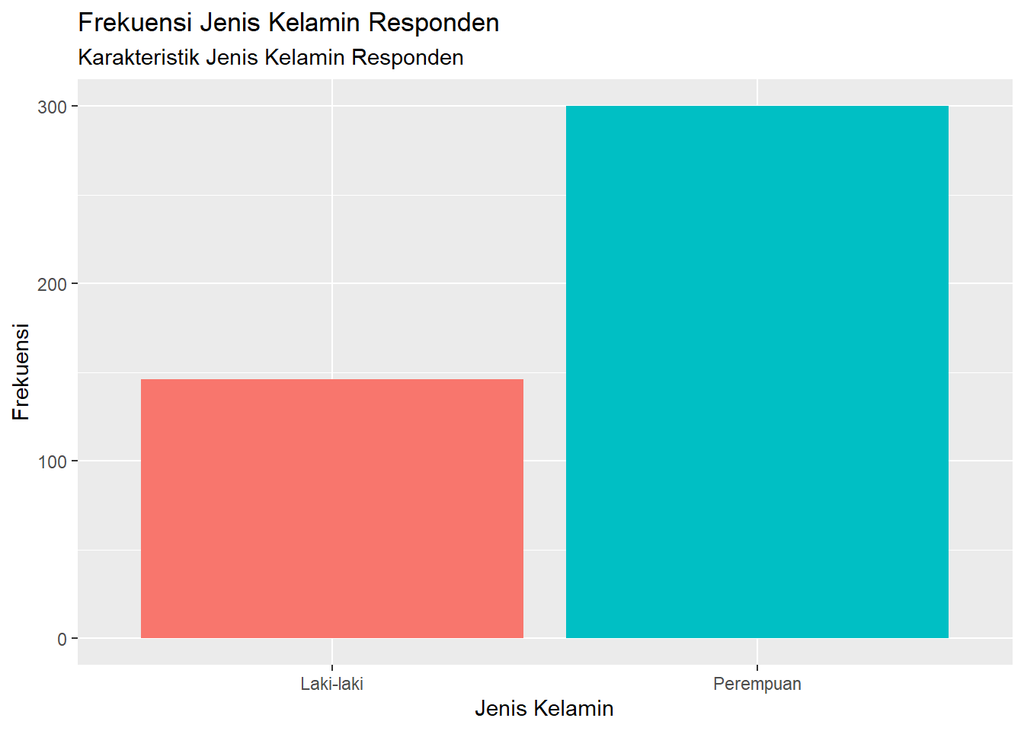

```r
# a) Jenis Kelamin Responden
jenis_kelamin <- internetdata %>%
  ggplot(aes(x = Sex, fill = Sex)) +
  geom_bar() +
  labs(title = "Frekuensi Jenis Kelamin Responden",
       subtitle = "Karakteristik Jenis Kelamin Responden",
       x = "Jenis Kelamin",
       y = "Frekuensi") +
  theme(legend.position = "none")

# b) Fakultas Responden
fakultas <- internetdata %>%
  ggplot(aes(x = Fakultas, fill = Fakultas)) +
  geom_bar() +
  labs(title = "Frekuensi Fakultas Responden",
       subtitle = "Karakteristik Fakultas responden",
       x = "Fakultas",
       y = "Frekuensi") +
  theme(legend.position = "none")

jenis_kelamin
```

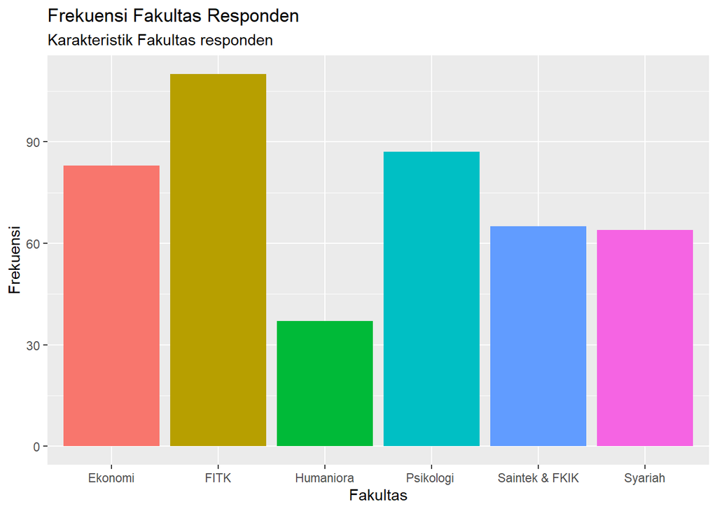

```r
fakultas
```

*Catatan*

- Sebaran responden menurut jenis kelamin adalah “Laki-laki” sebanyak 146 orang dan “Perempuan” 300 orang
- Untuk sebaran fakultas: Ekonimi = 83 orang, FITK = 110 orang, Humaniora = 37 orang, Psikologi 87 orang, Saintek = 65 orang, dan Syariah = 64 orang

## 3.2 Menyederhanakan Variabel Jenis Kelamin dan Fakultas

Dua visualisasi di atas dapat disederhanakan menjadi satu chart dengan cara mengisi chartnya dengan variabel lain

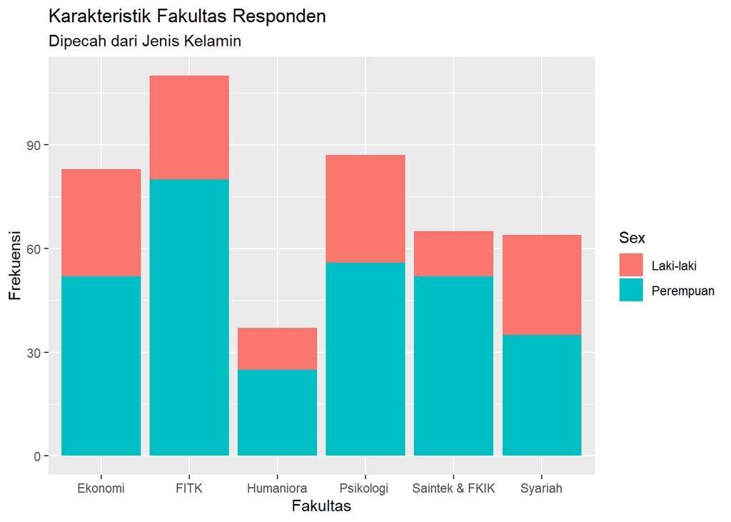

```r
# c) Menggabungkan variabel Sex dan Fakultas dalam satu chart (fill =)
internetdata %>%
  ggplot(aes(x = Fakultas, fill = Sex)) +
  geom_bar() +
  labs(title = "Karakteristik Fakultas Responden",
  subtitle = "Dipecah dari Jenis Kelamin",
       y = "Frekuensi",
       x = "Fakultas")
```

*Catatan*

- Alih-alih memisahkan dua kategori demografi Fakultas dan Sex, akan lebih sederhana jika disatukan dengan hasil yang sama

## 3.3 Menggunakan Facet Wrap untuk Menjabarkan Data

Kita juga dapat membuat visualisasi dengan facet_wrap untuk melihat lebih detail bagaimana karakteristik jenis kelamin dan fakultas dipecah menggunakan data koneksi

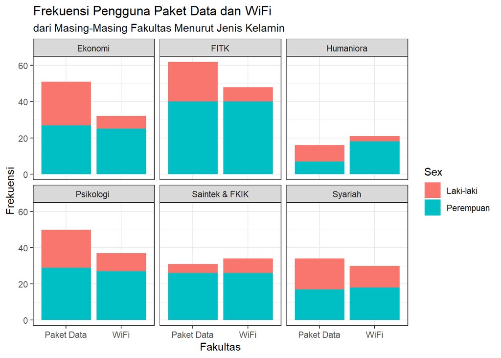

```r
# d) Mem-facet_wrap menggunakan variabel Koneksi
internetdata %>%
  ggplot(aes(x = Koneksi, fill = Sex)) +
  theme_bw() +
  facet_wrap(~ Fakultas) +
  geom_bar() +
  labs(title = "Frekuensi Pengguna Paket Data dan WiFi",
       subtitle = "dari Masing-Masing Fakultas Menurut Jenis Kelamin",
       x = "Fakultas",
       y = "Frekuensi")
```

*Catatan*

- Kita tidak bisa mentah-mentah menginterpretasikan data ini (i.e, pengguna paket data terbanyak dari FITK) karena jumlah responden per Fakultas yang tidak proporsional

## 3.4 Media Sosial Apa yang Paling Sering Digunakan oleh Mayoritas Responden?

Variabel MedSos menanyakan tentang jenis media sosial yang paling sering digunakan oleh responden.

- Peneliti menyediakan beberapa jawaban media sosial serta menyertakan kolom kosong untuk diisi responden

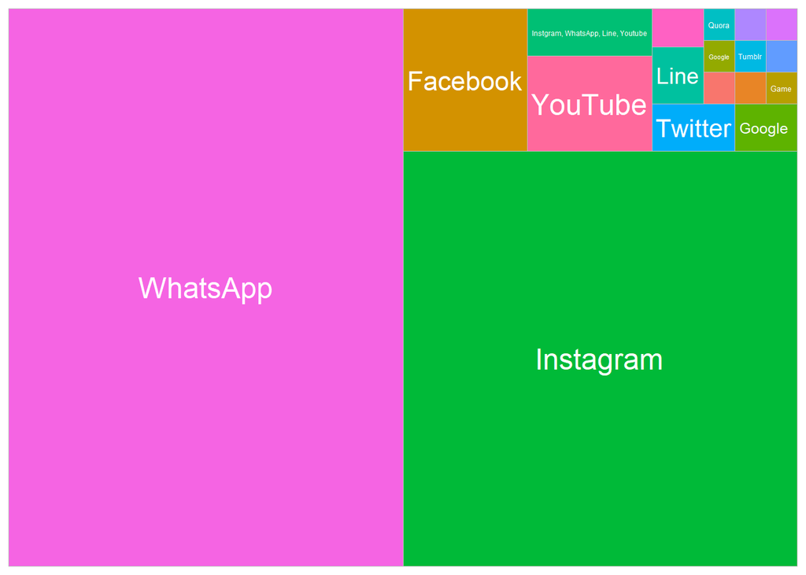

```r
treemap_medsos <- internetdata %>% count(MedSos)
#View(treemap_medsos) # untuk melihat lebih detail tentang data

treemap_medsos %>%
  ggplot(aes(fill = MedSos,
             area = n,
             label = MedSos)) +
  geom_treemap() +
  geom_treemap_text(colour = "white",
                    place = "centre") +
  labs("Media Sosial yang Sering Digunkan") +
  theme(legend.position = "none")
```

*Catatan*

## 3.5 Alasan Apa yang Mendasari Responden Mengakses Internet?

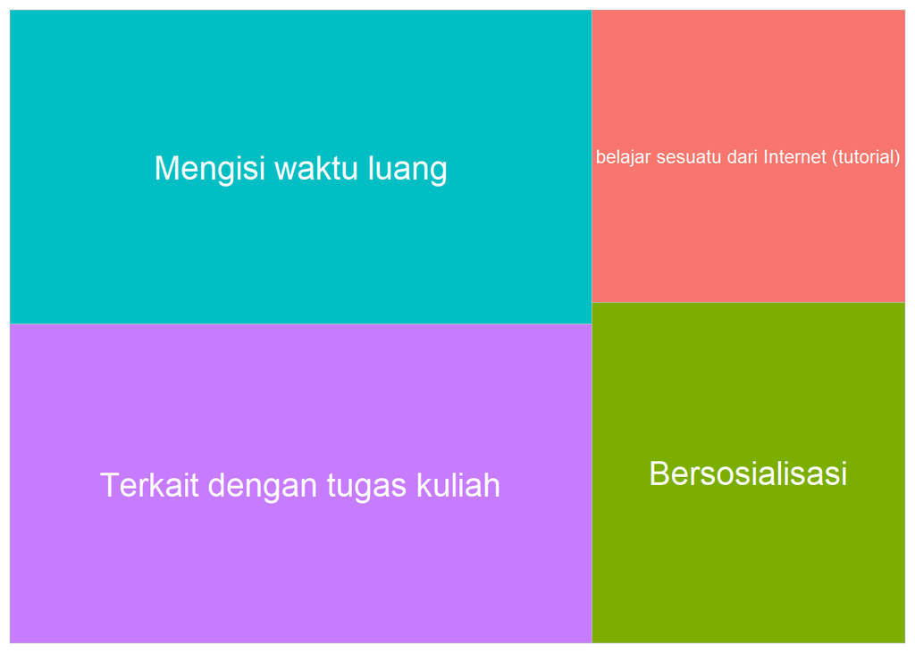

```r
treemap_alasan <- internetdata %>% count(Alasan)

treemap_alasan %>% ggplot(aes(fill = Alasan,
                            area = n,
                            label = Alasan)) +
  geom_treemap() +
  geom_treemap_text(colour = "white",
                    place = "centre") +
  labs("Alasan Penggunaan Internet") +
  theme(legend.position = "none")
```

*Catatan*

- Visualisasi treemap di atas menunjukkan bahwa mayoritas responden cenderung menggunakan internet karena terkait tugas kuliah dan mengisi waktu luang

## 3.6 Bagaimana tentang usia responden?

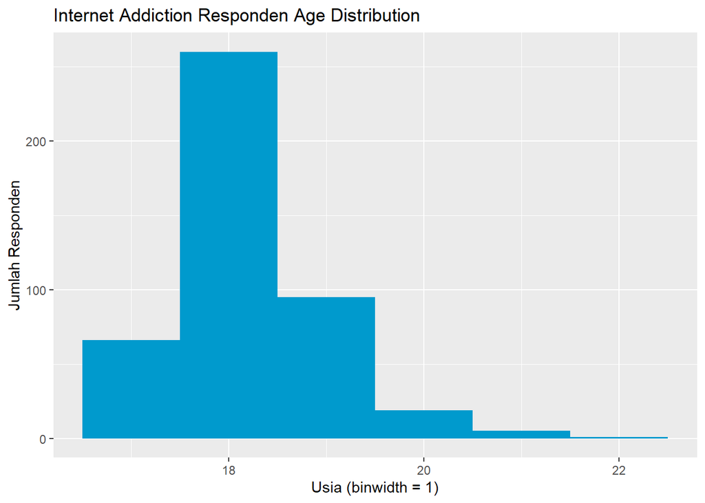

```r
internetdata %>% ggplot(aes(x = Usia)) +
  geom_histogram(binwidth = 1,  fill = "deepskyblue3") +
  labs(y = "Jumlah Responden",
       x = "Usia (binwidth = 1)",
       title = "Internet Addiction Responden Age Distribution")
```

*Catatan*

- Mayoritas responden berada pada usia 18 tahun (260 orang)
- Hanya 5 orang yang berusia 21 tahun dan 1 orang berusia 22 tahun

# 4 **Visualisasi dan Analisa Variabel Kategori Adiksi**

Menggunakan skor dari variabel internet addiction, kita membuat dua kategori. Kategori pertama adalah mereka yang masuk dalam kategori adiksi, sedang kategori kedua termasuk dalam kategori non adiksi.

## 4.1 Membuat visualisasi dari variabel “Kategori”

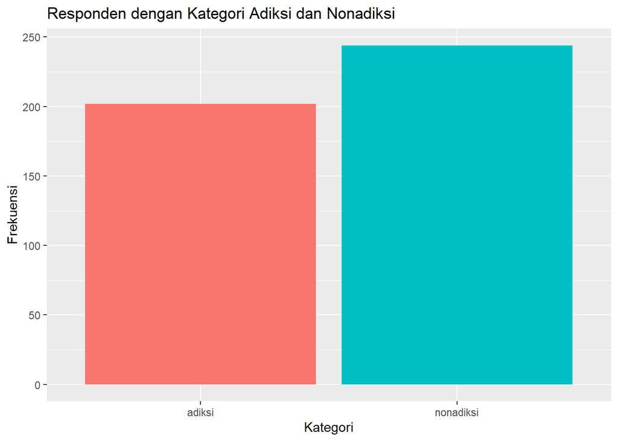

```r
kategori <- internetdata %>%
  ggplot(aes(x = Kategori,
             fill = Kategori)) +
  geom_bar() +
  labs(title = "Responden dengan Kategori Adiksi dan Nonadiksi",
       x = "Kategori",
       y = "Frekuensi") +
  theme(legend.position = "none")

kategori
```

```r
prop.table(table(internetdata$Kategori))
```

```
##
##    adiksi nonadiksi
## 0.4529148 0.5470852
```

*Catatan*

## 4.2 Kategori Kecanduan Berdasarkan Jenis Kelamin dan Usia

Pada bagian ini kita akan membandingkan frekuensi jenis kelamin dan usia dalam kategori adiksi dan nonadiksi

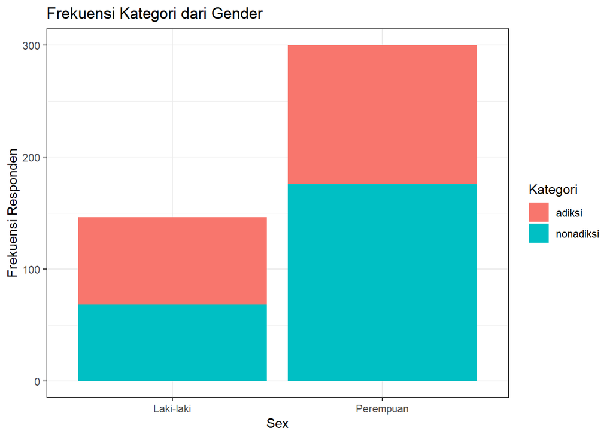

```r
kategori_sex <- internetdata %>%
  ggplot(aes(x = Sex, fill = Kategori)) +
  theme_bw() +
  geom_bar() +
  labs(y = "Frekuensi Responden",
       title = "Frekuensi Kategori dari Gender")

kategori_usia <- internetdata %>%
  ggplot(aes(x = Usia, fill = Kategori)) +
  theme_bw() +
  geom_bar() +
  labs(y = "Frekuensi Responden",
       title = "Frekuensi Kategori dari Usia")


kategori_sex
```

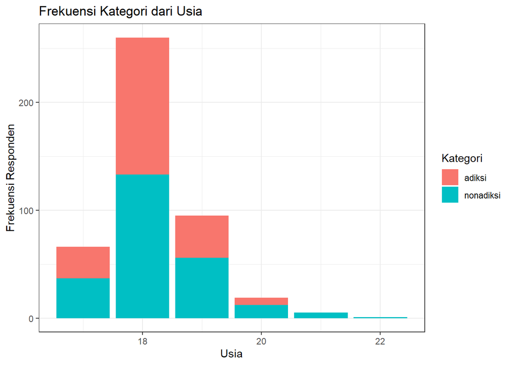

```r
kategori_usia
```

*Catatan*

## 4.3 Facet-Wrap Koneksi dari Jenis Kelamin Diisi dengan Variabel “Kategori”

Dalam bagian ini, saya mencoba membandingkan antara frekuensi dari variabel jenis kelamin dalam kategori adiksi dan nonadiksi dilihat pada jenis tipe koneksi (WiFi/Paket Data) yang digunakan

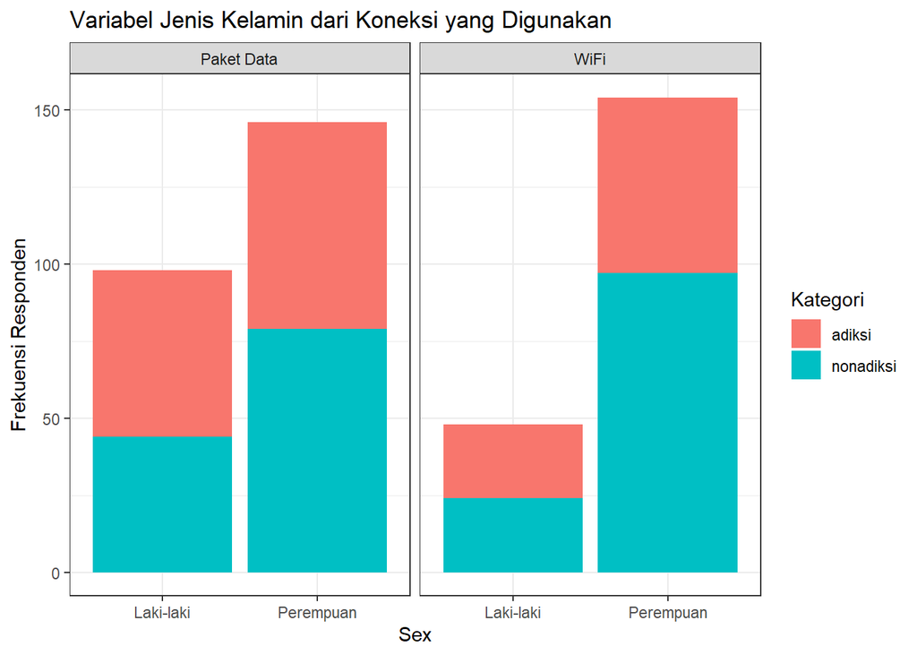

```r
internetdata %>%
  ggplot(aes(x = Sex, fill = Kategori)) +
  theme_bw() +
  facet_wrap(~ Koneksi) +
  geom_bar() +
  labs(y = "Frekuensi Responden",
       title = "Variabel Jenis Kelamin dari Koneksi yang Digunakan")
```

## 4.4 Menghubungkan variabel kategori, jenis kelamin dan koneksi

Bagian ini mencoba untuk menunjukkan keterkaitan antara beberapa variabel bertipe factor untuk dilihat alur keterkaitannya

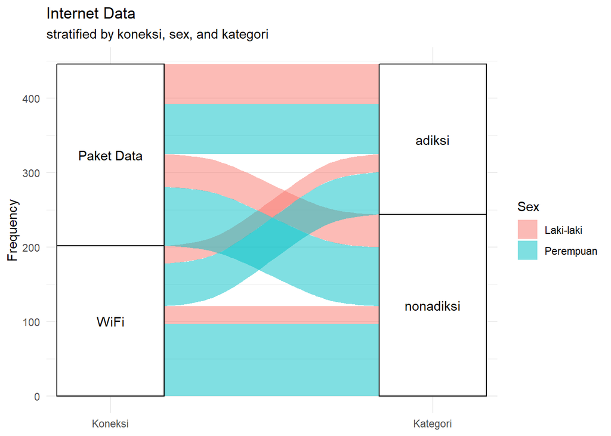

```r
internetall <- internetdata %>%
  group_by(Kategori, Sex, Koneksi) %>%
  count()

konekallu <- ggplot(internetall,
       aes(axis1 = Koneksi,
           axis2 = Kategori,
           y = n)) +
  geom_alluvium(aes(fill = Sex)) +
  geom_stratum() +
  geom_text(stat = "stratum",
            aes(label = after_stat(stratum))) +
  scale_x_discrete(limits = c("Koneksi", "Kategori"),
                   expand = c(.1, .1)) +
  labs(title = "Internet Data",
       subtitle = "stratified by koneksi, sex, and kategori",
       y = "Frequency") +
  theme_minimal()



durasiAllu <- internetdata %>%
  group_by(Durasi, Sex, Kategori) %>%
  count()

duraAlu <- ggplot(durasiAllu,
       aes(axis1 = Durasi,
           axis2 = Kategori,
           y = n)) +
  geom_alluvium(aes(fill = Sex)) +
  geom_stratum() +
  geom_text(stat = "stratum",
            aes(label = after_stat(stratum))) +
  scale_x_discrete(limits = c("Durasi", "Kategori"),
                   expand = c(.1, .1)) +
  labs(title = "Internet Data",
       subtitle = "stratified by durasi, sex, and kategori",
       y = "Frequency") +
  theme_minimal()


konekallu
```

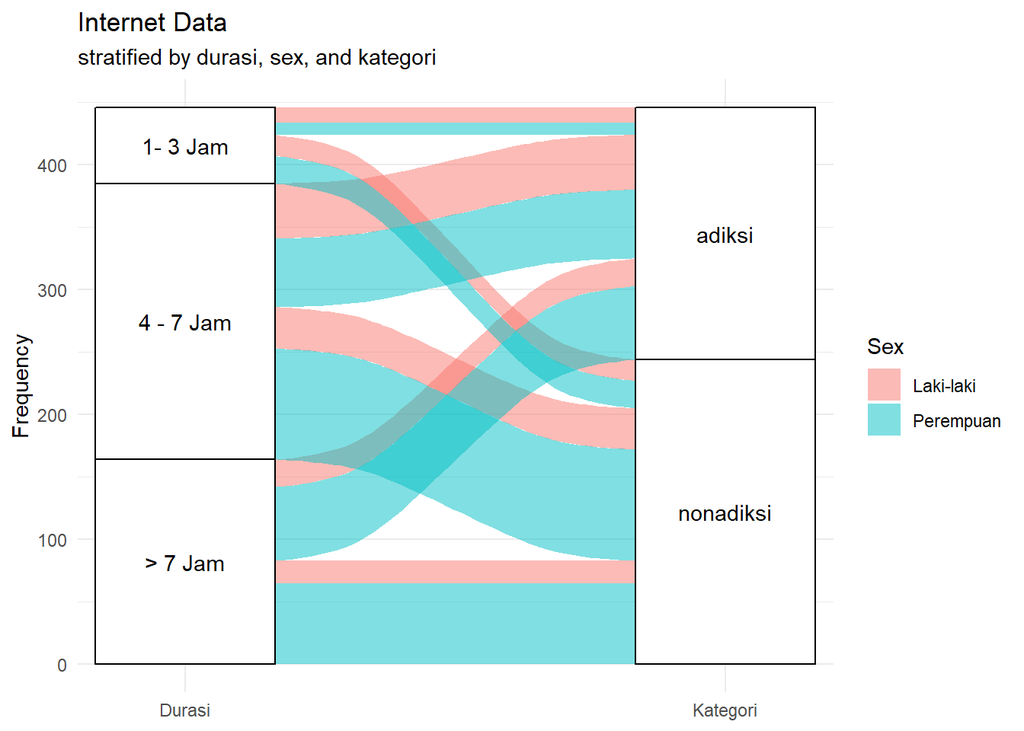

```r
duraAlu
```

## 4.5 Membuat diagram alluvial menggunakan 4 variabel

Bagian ini sejatinya sama dengan bagian sebelumnya, hanya di sini kita menggunakan axis yang lebih banyak untuk melihat keterkaita antar variabel factor yang dipilih

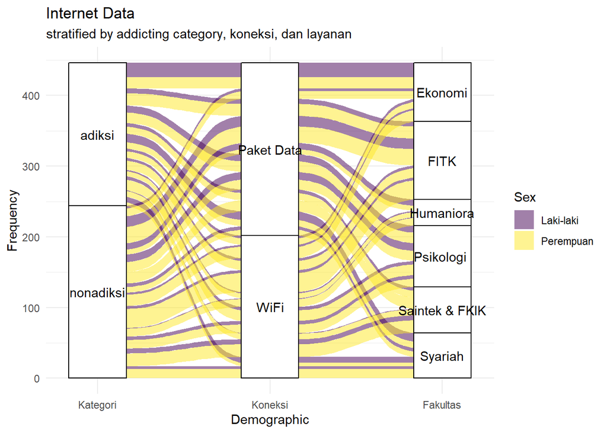

```r
internetall2 <- internetdata %>%
  group_by(Kategori, Sex, Koneksi, Fakultas) %>%
  count()

ggplot(internetall2,
       aes(axis1 = Kategori,
           axis2 = Koneksi,
           axis3 = Fakultas,
           y = n)) +
  geom_alluvium(aes(fill = Sex)) +
  geom_stratum() +
  geom_text(stat = "stratum",
            aes(label = after_stat(stratum))) +
  scale_x_discrete(limits = c("Kategori", "Koneksi", "Fakultas"),
                   expand = c(.1, .1)) +
  scale_fill_viridis_d() +
  labs(title = "Internet Data",
       subtitle = "stratified by addicting category, koneksi, dan layanan",
       y = "Frequency",
       x = "Demographic") +
  theme_minimal()
```

## 4.6 Melihat gambaran demografi Kategori, Jenis Kelamin, dan Koneksi

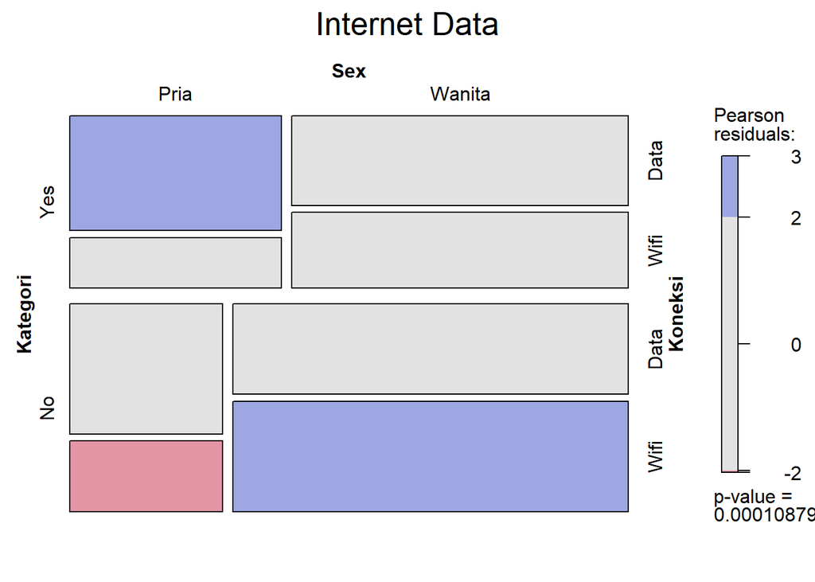

```r
jj <- xtabs(~Kategori + Sex + Koneksi, internetdata)

# mosaic(jj, main = "Internet Data") #ini memunculkan layer dasar

mosaic(jj,
       shade = T,
       legend = T,
       labeling_args = list(set_vernames = c(Sex = "Gender",
                                             Kategori = "Kategori Adiksi",
                                             Koneksi = "Tipe Koneksi")),
       set_labels = list(Kategori = c("Yes", "No"),
                         Sex = c("Pria", "Wanita"),
                         Koneksi = c("Data", "Wifi")),
       main = "Internet Data")
```

# 5 **Analisis Statistik dari Variabel IA, Depresi, Anxiety, dan Stress**

- SPOLER ALERT! Bagian ini akan ada banyak sekali angka, tetapi tenang saja. Terdapat visualisasi dan juga rangkuman dari angka-angka yang menyilaukan tersebut.

Setelah dirasa cukup dengan data demografi, data dari variabel skala psikologi juga harus dianalisis

Penelitian ini menggunakan dua skala alat ukur: IAT (Internet Addiction Test) untuk mengukur kecanduan internet yang dikembangkan oleh Young. Sedangkan untuk mengukur depresi, anxiety, dan stress, digunakan skala DASS-42 (Depression, Anxiety, and Stress Scale 42 item) terjemah bahasa Indonesia.

## 5.1 Summary korelasi 4 variabel psikologis

Uji Statistik yang pertama dilakukan adalah dengan menemukan angka korelasi dari empat variabel psikologis: Internet addiction, depresi, anxiety, dan stress

```r
#Menggunakan
#library(correlation)

newdata <- select(internetdata, IA, Depresi, Anxiety, Stress)
correlation::correlation(newdata, include_factors = T, method = "auto")
```

```
## Parameter1 | Parameter2 |    r |       95% CI |     t |  df |      p |  Method | n_Obs
## --------------------------------------------------------------------------------------
## IA         |    Depresi | 0.36 | [0.28, 0.44] |  8.14 | 444 | < .001 | Pearson |   446
## IA         |    Anxiety | 0.44 | [0.36, 0.51] | 10.20 | 444 | < .001 | Pearson |   446
## IA         |     Stress | 0.48 | [0.41, 0.55] | 11.59 | 444 | < .001 | Pearson |   446
## Depresi    |    Anxiety | 0.72 | [0.67, 0.76] | 21.68 | 444 | < .001 | Pearson |   446
## Depresi    |     Stress | 0.71 | [0.66, 0.75] | 21.24 | 444 | < .001 | Pearson |   446
## Anxiety    |     Stress | 0.79 | [0.75, 0.82] | 27.31 | 444 | < .001 | Pearson |   446
```

*Catatan*

Variabel depresei, anxiety, dan stress memiliki angka korelasi yang cukup tinggi (dep ~ anx = 0.72 p < 0.05, dep ~ str = 0.71 p < 0.05, anx = str = 0.79 p < 0.05)

## 5.2 Membuat tabel angka korelasi dari 4 variabel skala psikologis

Selanjutnya, angka korelasi yang telah kita dapat, akan kita visualkan menggunakan diagram tangga untuk mempermudah mengetahui detail nomornya

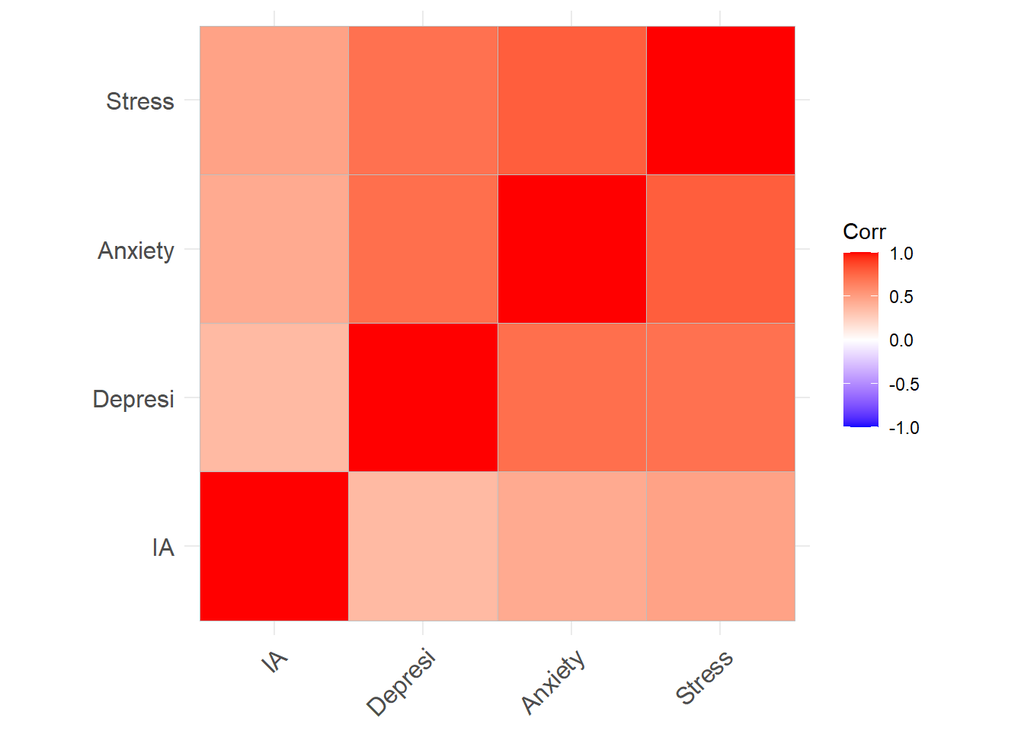

```r
intr <- dplyr::select_if(newdata, is.numeric)
r <- cor(intr, use="complete.obs")
rr <- ggcorrplot(r) #Visual diagram kotak

rr
```

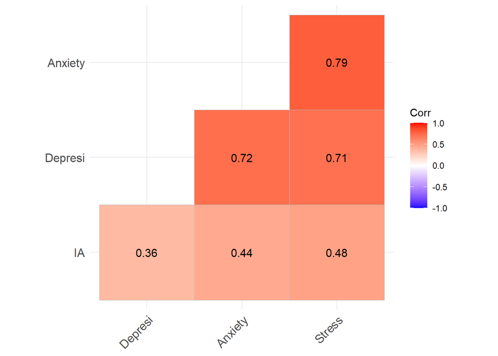

```r
ggcorrplot(r,
           hc.order = T,
           type = "lower",
           lab = T) #Visual diagram tangga
```

## 5.3 Membuat point chart korelasi dari variabel internet adiksi dan depresi, anxiety, dan stress dibedakan dari jenis kelamin

Guna mengetahui trend dari korelasi internet addiction dengan depresi, anxiety, dan stres, kita akan menggunakan visualisasi point char dengan line = linear regression model sebagai penentu trend.

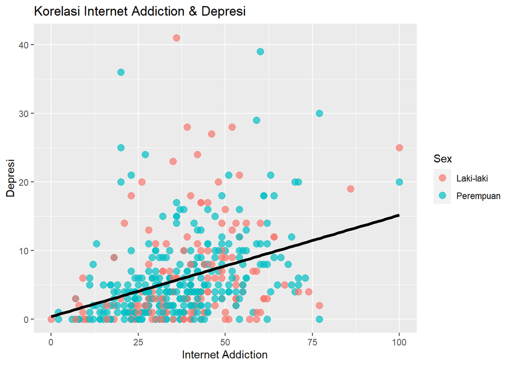

```r
#Internet Addiction ~ Depression
ia_depres <- ggplot(data = internetdata,
                    aes(x = IA,
                        y = Depresi,
                        color = Sex)) +
  geom_point(alpha = .7,
             size = 3) +
  geom_smooth(method = "lm",
              se = FALSE,
              size = 1.5,
              col = "black") +
  labs(y = "Depresi",
       x = "Internet Addiction",
       title = "Korelasi Internet Addiction & Depresi")
ia_depres
```

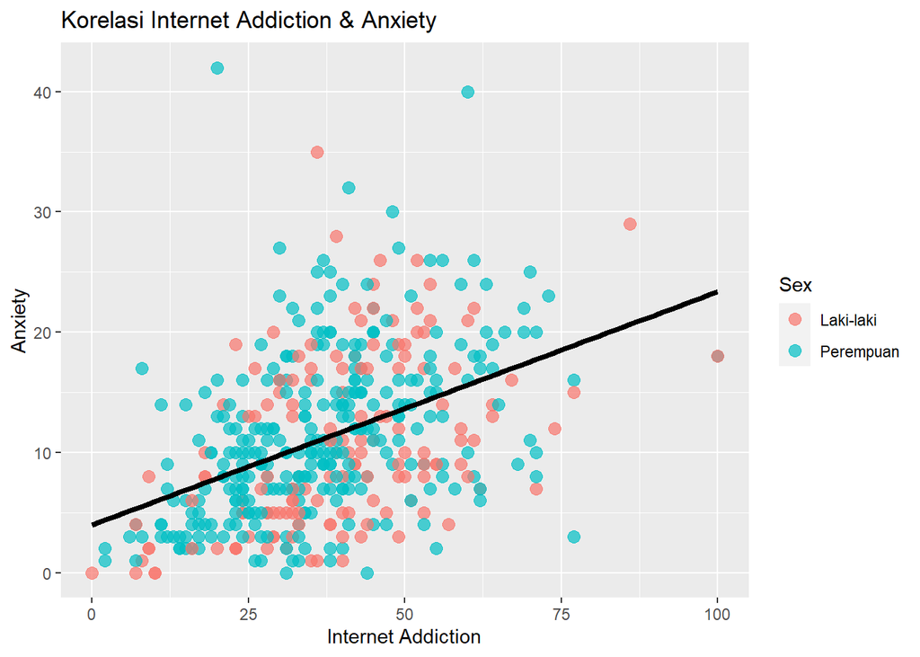

```r
#Internet Addiction ~ Anxiety
ia_anxiety <- ggplot(data = internetdata,
                    aes(x = IA,
                        y = Anxiety,
                        color = Sex)) +
  geom_point(alpha = .7,
             size = 3) +
  geom_smooth(method = "lm",
              se = FALSE,
              size = 1.5,
              col = "black") +
  labs(y = "Anxiety",
       x = "Internet Addiction",
       title = "Korelasi Internet Addiction & Anxiety")
ia_anxiety
```

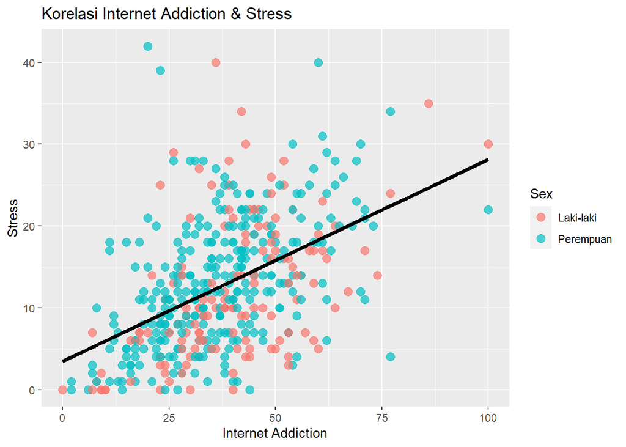

```r
#Internet Addiction ~ Stress
ia_stress <- ggplot(data = internetdata,
                    aes(x = IA,
                        y = Stress,
                        color = Sex)) +
  geom_point(alpha = .7,
             size = 3) +
  geom_smooth(method = "lm",
              se = FALSE,
              size = 1.5,
              col = "black") +
  labs(y = "Stress",
       x = "Internet Addiction",
       title = "Korelasi Internet Addiction & Stress")
ia_stress
```

## 5.4 Korelasi menggunakan chord diagram

Kita juga dapat menggunakan chord diagram untuk membuat visualisasi korelasi dari variabel interenet addiction, depresi, anxiety, dan juga stress.

```r
#Making matrix correlation
library(circlize)
rdat <- select(internetdata, IA, Depresi, Anxiety, Stress)

cordat <- cor(rdat)
round(cordat, 2)
```

```
##           IA Depresi Anxiety Stress
## IA      1.00    0.36    0.44   0.48
## Depresi 0.36    1.00    0.72   0.71
## Anxiety 0.44    0.72    1.00   0.79
## Stress  0.48    0.71    0.79   1.00
```

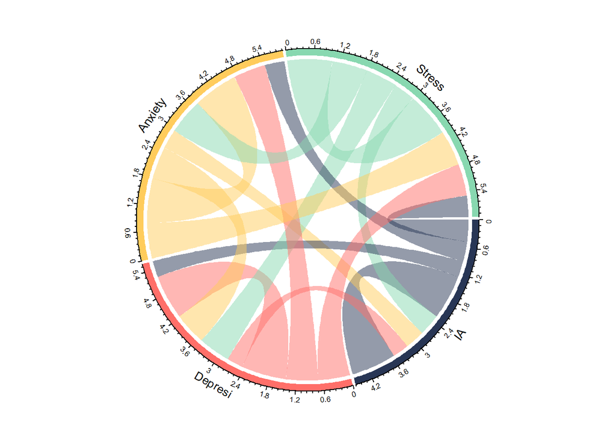

```r
grid.col <- c(IA = "#283655", Depresi = "#ff6f69", Anxiety = "#ffcc5c", Stress = "#88d8b0" )
chordDiagram(round(cordat, 2), grid.col = grid.col)
```

```r
#circos.clear()
```

Atau dengan chord diagram interaktif

```r
#Menggunakan library(chorddiag)
library(chorddiag)
intcordiacho <- chorddiag(round(cordat, 2))
intcordiacho
```

[interactive chart not shown]

## 5.5 Uji MANOVA menggunakan kategori IA sebagai variabel independent

Pada penelitian ini, interent addiction merupakan variabel bebas (independent variable) sedangkan depresi, anxiety, dan stres merupakan variabel terikat (dependent variabel).

Uji statistik selanjutnya adalah menggunakan metode multivariate analysis of variance (MANOVA). Hal ini memungkinkan kita menguji variabel independen kategorial IA (adiksi dan nonadiksi) dengan variabel dependent (depresi, anxiety, dan stress) untuk mengetahui apakah terdapat perbedaan yang nyata pada kategori IA terhadap 3 variabel dependent

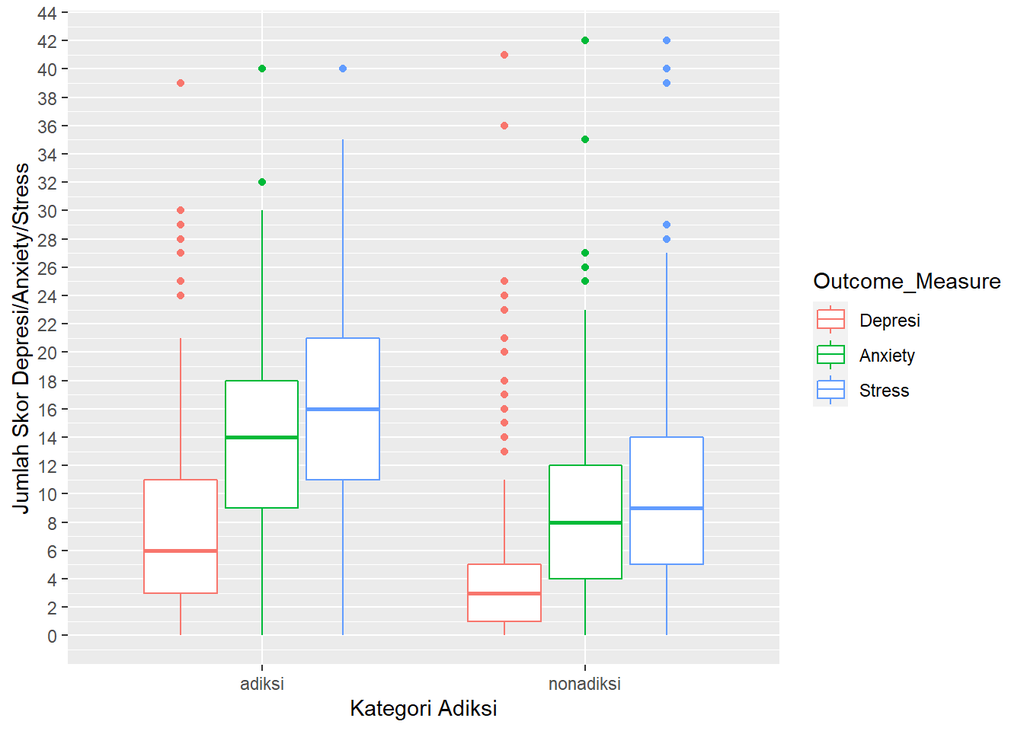

```r
# Prepare and Explore Data untuk Manova

manova_kat <- select(internetdata, Depresi, Anxiety, Stress, Kategori)
manova_kat$Kategori <- factor(manova_kat$Kategori, levels = c("adiksi", "nonadiksi"))

#Pake library(rehsape2) untuk melt()
katmelt <- melt(manova_kat, id = c("Kategori"), measured = c("Depresi", "Anxiety", "Stress"))
names(katmelt) <- c("Kategori", "Outcome_Measure", "Frequency")

katmeltboxp <- katmelt %>%
  ggplot(aes(Kategori, Frequency, col = Outcome_Measure)) +
  geom_boxplot() +
  labs(x = "Kategori Adiksi",
       y = "Jumlah Skor Depresi/Anxiety/Stress",
       color = "Outcome_Measure") +
       scale_y_continuous(breaks = seq(0, 60, by = 2))

katmeltboxp
```

## 5.6 Analisis Manova

Karena ini uji statistik, maka harus dibuat asumsi atau hipotesis dasarnya dulu

Ho = Variabel depresi, anxiety, dan stres secara bersama-sama tidak menunjukkan perbedaan nyata pada kategori “adiksi” dan “noadiksi” -atau bisa dikatakan, skor mean depresi, anxiety, dan stres sama pada kategori adiksi dan nonadiksi

Ha = Variabel depresi, anxiety, dan stres secara bersama-sama menunjukkan perbedaan nyata pada kategori “adiksi” dan “nonadiksi” -bisa juga dikatakan, skor mean depresi, anxiety, dan stres berbeda pada kategori adiksi dan nonadiksi

```r
manoutcome <- cbind(manova_kat$Depresi, manova_kat$Anxiety, manova_kat$Stress)
adiksiModel <- manova(manoutcome ~ Kategori, data = manova_kat)
summary(adiksiModel, intercept = TRUE)
```

```
##              Df  Pillai approx F num Df den Df    Pr(>F)
## (Intercept)   1 0.78405   534.94      3    442 < 2.2e-16 ***
## Kategori      1 0.14927    25.85      3    442 2.005e-15 ***
## Residuals   444
## ---
## Signif. codes:  0 '***' 0.001 '**' 0.01 '*' 0.05 '.' 0.1 ' ' 1
```

```r
summary(adiksiModel, intercept=TRUE, test="Wilks")
```

```
##              Df   Wilks approx F num Df den Df    Pr(>F)
## (Intercept)   1 0.21595   534.94      3    442 < 2.2e-16 ***
## Kategori      1 0.85073    25.85      3    442 2.005e-15 ***
## Residuals   444
## ---
## Signif. codes:  0 '***' 0.001 '**' 0.01 '*' 0.05 '.' 0.1 ' ' 1
```

```r
summary(adiksiModel, intercept=TRUE, test="Hotelling")
```

```
##              Df Hotelling-Lawley approx F num Df den Df    Pr(>F)
## (Intercept)   1           3.6308   534.94      3    442 < 2.2e-16 ***
## Kategori      1           0.1755    25.85      3    442 2.005e-15 ***
## Residuals   444
## ---
## Signif. codes:  0 '***' 0.001 '**' 0.01 '*' 0.05 '.' 0.1 ' ' 1
```

```r
summary(adiksiModel, intercept=TRUE, test="Roy")
```

```
##              Df    Roy approx F num Df den Df    Pr(>F)
## (Intercept)   1 3.6308   534.94      3    442 < 2.2e-16 ***
## Kategori      1 0.1755    25.85      3    442 2.005e-15 ***
## Residuals   444
## ---
## Signif. codes:  0 '***' 0.001 '**' 0.01 '*' 0.05 '.' 0.1 ' ' 1
```

*Catatan*

- Tes dilakukan menggunakan prosedur Pillai (0.15), Wilks (0.85), Hotelling (0.18), dan Roy (0.18). Semua prosedur menunjukkan angka signifikansi < 0.05 (note: 2.2e-16 = 0.00000000000000022, dengan 15 nol setelah titik)
- Dengan demikian maka Ho ditolak = Variabel depresi, anxiety, dan stres secara bersama-sama menunjukkan tingkat perbedaan yang nyata pada kategori adiksi (Mungkin saja responden dengan kategori adiksi internet lebih mungkin mengalami depresi, anxiety, dan stress, dibandingkan mereka yang berada dalam kategori nonadiksi)

## 5.7 Follow-up analysis: univariate test statistics

```r
#Simply dengan memanggil
summary.aov(adiksiModel)
```

```
##  Response 1 :
##              Df  Sum Sq Mean Sq F value    Pr(>F)
## Kategori      1  1513.2 1513.17  39.543 7.689e-10 ***
## Residuals   444 16990.5   38.27
## ---
## Signif. codes:  0 '***' 0.001 '**' 0.01 '*' 0.05 '.' 0.1 ' ' 1
##
##  Response 2 :
##              Df  Sum Sq Mean Sq F value    Pr(>F)
## Kategori      1  2874.7 2874.65  67.369 2.466e-15 ***
## Residuals   444 18945.7   42.67
## ---
## Signif. codes:  0 '***' 0.001 '**' 0.01 '*' 0.05 '.' 0.1 ' ' 1
##
##  Response 3 :
##              Df  Sum Sq Mean Sq F value    Pr(>F)
## Kategori      1  3912.1  3912.1  69.594 9.277e-16 ***
## Residuals   444 24958.7    56.2
## ---
## Signif. codes:  0 '***' 0.001 '**' 0.01 '*' 0.05 '.' 0.1 ' ' 1
```

*Catatan*

- Tabel berlabel Respon 1 untuk variabel Depresi, Respon 2 untuk variabel Anxiety, dan Respon 3 untuk variabel Stress.
- Perhatikan bahwa nilai F dan nilai p dari analisis follow-up MANOVA ini identik dengan yang diperoleh jika dilakukan analisa one-way ANOVA pada setiap variabel dependen.
- Nilai p menunjukkan bahwa terdapat perbedaan yang signifikan antara kategori adiksi dan nonadiksi dalam hal depresi, anxiety, dan stress (p < .05)

## 5.8 Eksplorasi data untuk melakukan t-test

Persiapan dan eksplorasi Data (means) depresi, anxiety, dan stress masing-masing jenis kelamin responden yang termasuk dalam kategori adiksi internet

```r
#Persiapan dan eksplorasi data
#Membuat data khusus untuk uji t

tadiksites <- select(internetdata, Sex, IA, Depresi, Anxiety, Stress, Kategori) #newdata
tadiksites$Kategori <- factor(tadiksites$Kategori, levels = c("nonadiksi", "adiksi"))
str(tadiksites)
```

```
## 'data.frame':    446 obs. of  6 variables:
##  $ Sex     : Factor w/ 2 levels "Laki-laki","Perempuan": 1 1 1 1 2 1 1 2 2 2 ...
##  $ IA      : int  21 40 86 18 13 23 36 2 54 40 ...
##  $ Depresi : int  14 18 19 2 2 0 41 1 0 0 ...
##  $ Anxiety : int  14 17 29 8 3 2 35 2 7 7 ...
##  $ Stress  : int  14 21 35 7 1 0 40 0 3 1 ...
##  $ Kategori: Factor w/ 2 levels "nonadiksi","adiksi": 1 2 2 1 1 1 1 1 2 2 ...
```

```r
dd <- filter(tadiksites, Kategori == "adiksi")

#cek nilai rata-rata antara jenis kelamin dalam kategori adiksi  pada variabel depresi, anxiety, dan stress

meanSexDep <- group_by(dd, Sex) %>%
  summarize(
    count = n(),
    mean = round(mean(Depresi, na.rm = TRUE), 2),
    sd = round(sd(Depresi, na.rm = TRUE), 2)
  )
kbl(meanSexDep, caption = "Perbandingan mean jenis kelamin dalam kategori adiksi pada varibale depresi") %>%
   kable_styling(bootstrap_options = "striped", position = "left")
```

Perbandingan mean jenis kelamin dalam kategori adiksi pada varibale depresi

| Sex | count | mean | sd |
| --- | --- | --- | --- |
| Laki-laki | 78 | 7.99 | 7.36 |
| Perempuan | 124 | 7.89 | 6.41 |

```r
meanSexAnx <- group_by(dd, Sex) %>%
  summarize(
    count = n(),
    mean = round(mean(Anxiety, na.rm = TRUE),  2),
    sd = round(sd(Anxiety, na.rm = TRUE), 2)
  )
kbl(meanSexAnx, caption = "Perbandingan mean jenis kelamin dalam kategori adiksi pada varibale anxiety") %>%
  kable_styling(bootstrap_options = "striped", position = "left")
```

Perbandingan mean jenis kelamin dalam kategori adiksi pada varibale anxiety

| Sex | count | mean | sd |
| --- | --- | --- | --- |
| Laki-laki | 78 | 13.36 | 6.66 |
| Perempuan | 124 | 14.46 | 6.64 |

```r
meanSexStr <- group_by(dd, Sex) %>%
  summarize(
    count = n(),
    mean = round(mean(Stress, na.rm = TRUE), 2),
    sd = round(sd(Stress, na.rm = TRUE), 2)
  )
kbl(meanSexStr, caption = "Perbandingan mean jenis kelamin dalam kategori adiksi pada varibale stress") %>%
  kable_styling(bootstrap_options = "striped", position = "left")
```

Perbandingan mean jenis kelamin dalam kategori adiksi pada varibale stress

| Sex | count | mean | sd |
| --- | --- | --- | --- |
| Laki-laki | 78 | 15.14 | 7.93 |
| Perempuan | 124 | 16.49 | 7.24 |

*Catatan* Dari analisis di atas menunjukkan bahwa terdapat perbedaan nilai rata-rata antara laki-laki dan perempuan dalam kategori adiksi internet dalam skor depresi, anxiety, dan stres. Namun, apakah perbedaan ini signifikan? Maka dari itu harus dilakukan t-test (dalam hal ini two independent atau unpaired t-test)

## 5.9 t-test untuk membandingkan mean jenis kelamin dalam kategori adiksi pada variabel psikologis

Setelah mengetahui bahwa terdapat perbedaan mean (nilai rata-rata) antara jenis kelamin laki-laki dan perempuan dalam kategori adiksi pada variabel depresi, anxiety, dan stress, selanjutnya dilakukan uji-t untuk mengetahui apakah perbedaan nilai rerata ini signifikan

```r
#Uji t-test
t.test(Depresi ~ Sex, data = dd, var.equal = TRUE)
```

```
##
##  Two Sample t-test
##
## data:  Depresi by Sex
## t = 0.10198, df = 200, p-value = 0.9189
## alternative hypothesis: true difference in means is not equal to 0
## 95 percent confidence interval:
##  -1.835146  2.035311
## sample estimates:
## mean in group Laki-laki mean in group Perempuan
##                7.987179                7.887097
```

```r
t.test(Anxiety ~ Sex, data = dd, var.equal = TRUE)
```

```
##
##  Two Sample t-test
##
## data:  Anxiety by Sex
## t = -1.1462, df = 200, p-value = 0.2531
## alternative hypothesis: true difference in means is not equal to 0
## 95 percent confidence interval:
##  -2.9942903  0.7928842
## sample estimates:
## mean in group Laki-laki mean in group Perempuan
##                13.35897                14.45968
```

```r
t.test(Stress ~ Sex, data = dd, var.equal = TRUE)
```

```
##
##  Two Sample t-test
##
## data:  Stress by Sex
## t = -1.2444, df = 200, p-value = 0.2148
## alternative hypothesis: true difference in means is not equal to 0
## 95 percent confidence interval:
##  -3.491656  0.789836
## sample estimates:
## mean in group Laki-laki mean in group Perempuan
##                15.14103                16.49194
```

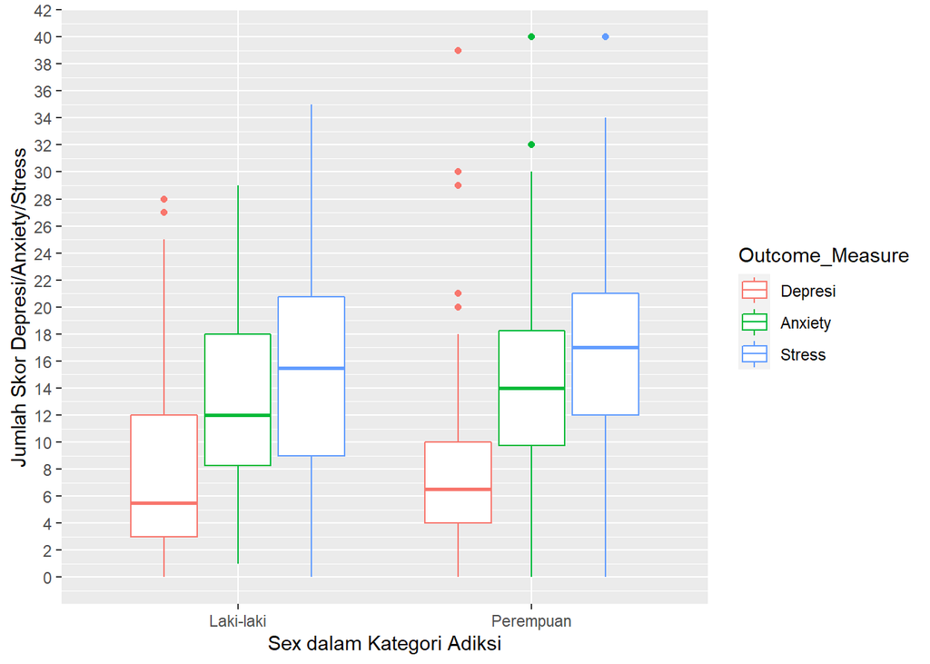

```r
#Visualisasinya
ttespr <- select(dd, Sex, Depresi, Anxiety, Stress)
ttespr$Sex <- factor(ttespr$Sex, levels = c("Laki-laki", "Perempuan"))

#Pake library(rehsape2) untuk melt()
ttesprmelt <- melt(ttespr, id = c("Sex"), measured = c("Depresi", "Anxiety", "Stress"))
names(ttesprmelt) <- c("Sex", "Outcome_Measure", "Frequency")

ttesbxpl <- ttesprmelt %>%
  ggplot(aes(Sex, Frequency, col = Outcome_Measure)) +
  geom_boxplot() +
  labs(x = "Sex dalam Kategori Adiksi",
       y = "Jumlah Skor Depresi/Anxiety/Stress",
       color = "Outcome_Measure") +
  scale_y_continuous(breaks = seq(0, 60, by = 2))

ttesbxpl
```

*Catatan* * Pada uji-t di atas, kita mengetahui bahwa nilai t dari variabel depresi = 0.10, anxiety = -1.146, dan stres = -1.24.

- Pada uji di atas juga ditemukan bahwa mean jenis kelamin dalam variabel depresi berbeda (laki-laki = 7.99, perempuan = 7.89). Begitu juga dalam variabel anxiety (laki-laki = 13.36, perempuan = 14.46) dan stres (laki-laki = 15.14, perempuan 16.5)
- Namun, ditemukan juga bahwa perbedaan skor rata-rata ini tidak signifikan. Ketiga variabel (depresi, anxiety, dan stress) memiliki nilai p > 0.05 (p = 0.92, p = 0.25, dan p = 0.21 secara berturut-turut)

Dengan demikian dapat kita katakan bahwa responden dalam kategori adiksi, tidak ada perbedaan antara laki-laki dan perempuan pada skor depresi, anxiety, dan juga stres.

Dari visualisasi boxplot juga menunjukkan bahwa pada masing-masing jenis kelamin, nilai rerata pada masing-masing variabel tidak menunjukkan perbedaan yang kontras.

Terima Kasih